# MDD_SRH

Sophia Halliday

2024-02-16

## Goals and Expectations

The goal of this challenge is to assess your capability in designing your own study given a problem statement and data at hand, consider the potential strengths and limitations of applying various analytical techniques, and assess your ability in “getting your hands dirty” with real-world data.

```r
demographics <- read.csv("~/Github/Holmusk_MDD/SDS RWE Data Challenge Dataset/demographics.csv")
clinical_data <- read.csv("~/Github/Holmusk_MDD/SDS RWE Data Challenge Dataset/clinical_data.csv")
bill_id <- read.csv("~/Github/Holmusk_MDD/SDS RWE Data Challenge Dataset/bill_id.csv")
bill_amount <- read.csv("~/Github/Holmusk_MDD/SDS RWE Data Challenge Dataset/bill_amount.csv")
```

Given that there is a common id among three datasets and another common id between two, we can merge all data together if necessary. For the chosen question and time constraints, there is no need to involve costings currently.

```r
Data1 <- merge(demographics, clinical_data, by.x = "patient_id", by.y= "id" )
```

Summarising all variables will be helpful in seeing how the data is coded and how it may need cleaned.

```r
st(Data1)
```

Summary Statistics

| Variable | N | Mean | Std. Dev. | Min | Pctl. 25 | Pctl. 75 | Max |
| --- | --- | --- | --- | --- | --- | --- | --- |
| gender | 3400 |  |  |  |  |  |  |
| … f | 116 | 3% |  |  |  |  |  |
| … Female | 1586 | 47% |  |  |  |  |  |
| … m | 202 | 6% |  |  |  |  |  |
| … Male | 1496 | 44% |  |  |  |  |  |
| race | 3400 |  |  |  |  |  |  |
| … chinese | 356 | 10% |  |  |  |  |  |
| … Chinese | 1810 | 53% |  |  |  |  |  |
| … India | 114 | 3% |  |  |  |  |  |
| … Indian | 230 | 7% |  |  |  |  |  |
| … Malay | 707 | 21% |  |  |  |  |  |
| … Others | 183 | 5% |  |  |  |  |  |
| resident_status | 3400 |  |  |  |  |  |  |
| … Foreigner | 161 | 5% |  |  |  |  |  |
| … PR | 515 | 15% |  |  |  |  |  |
| … Singapore citizen | 696 | 20% |  |  |  |  |  |
| … Singaporean | 2028 | 60% |  |  |  |  |  |
| medical_history_dia | 3400 | 0.17 | 0.37 | 0 | 0 | 0 | 1 |
| medical_history_sud | 3167 | 0.31 | 0.46 | 0 | 0 | 1 | 1 |
| medical_history_hbp | 3400 |  |  |  |  |  |  |
| … 0 | 2176 | 64% |  |  |  |  |  |
| … 1 | 348 | 10% |  |  |  |  |  |
| … No | 761 | 22% |  |  |  |  |  |
| … Yes | 115 | 3% |  |  |  |  |  |
| medical_history_ren | 3400 | 0.052 | 0.22 | 0 | 0 | 0 | 1 |
| medical_history_tum | 3096 | 0.064 | 0.24 | 0 | 0 | 0 | 1 |
| medical_history_anx | 3400 | 0.25 | 0.44 | 0 | 0 | 1 | 1 |
| medical_history_mood | 3400 | 0.25 | 0.44 | 0 | 0 | 1 | 1 |
| trt_anx | 3400 | 0.5 | 0.5 | 0 | 0 | 1 | 1 |
| trt_con | 3400 | 0.59 | 0.49 | 0 | 0 | 1 | 1 |
| trt_adt | 3400 | 0.82 | 0.38 | 0 | 1 | 1 | 1 |
| trt_ssr | 3400 | 0.52 | 0.5 | 0 | 0 | 1 | 1 |
| trt_the | 3400 | 0.82 | 0.38 | 0 | 1 | 1 | 1 |
| trt_oth | 3400 | 0.74 | 0.44 | 0 | 0 | 1 | 1 |
| symptom_1 | 3400 | 0.62 | 0.49 | 0 | 0 | 1 | 1 |
| symptom_2 | 3400 | 0.66 | 0.47 | 0 | 0 | 1 | 1 |
| symptom_3 | 3400 | 0.54 | 0.5 | 0 | 0 | 1 | 1 |
| symptom_4 | 3400 | 0.73 | 0.45 | 0 | 0 | 1 | 1 |
| symptom_5 | 3400 | 0.53 | 0.5 | 0 | 0 | 1 | 1 |
| weight | 3400 | 79 | 11 | 48 | 71 | 86 | 121 |
| height | 3400 | 165 | 7 | 151 | 160 | 170 | 186 |
| cgis_adm | 3400 | 4.3 | 1.3 | 1 | 3.8 | 5 | 7 |
| cgis_dis | 3400 | 3.9 | 1.1 | 1 | 3 | 5 | 6 |
| gaf_lv | 3400 | 5.8 | 1.3 | 1 | 5 | 7 | 8 |

This shows us many things. The variables are coded differently even within each individual group. For example Gender is given by ‘m’, ‘f’, ‘Female’ and ‘Male’. This needs recoded into correct groups.

```r
Data1$gender[Data1$gender == 'f'] <- "Female"
Data1$gender[Data1$gender == 'm'] <- "Male"
table(Data1$gender)
```

```
##
## Female   Male
##   1702   1698
```

Now we have correct variable coding for gender. Race also has the same issue.

```r
Data1$race[Data1$race == 'chinese'] <- "Chinese"
Data1$race[Data1$race == 'India'] <- "Indian"
table(Data1$race)
```

```
##
## Chinese  Indian   Malay  Others
##    2166     344     707     183
```

```r
Data1$medical_history_hbp[Data1$medical_history_hbp == 'No'] <- "0"
Data1$medical_history_hbp[Data1$medical_history_hbp == 'Yes'] <- "1"
table(Data1$medical_history_hbp)
```

```
##
##    0    1
## 2937  463
```

There are also a few variables that need to be re-classified to character to be treated correctly in analysis .

There are 3000 unique ID’s.

```r
length(unique(Data1$patient_id))
```

```
## [1] 3000
```

```r
st(Data1)
```

Summary Statistics

[output not shown]

We can give a nicer summary

```r
skim(Data1)
```

Data summary

| Name | Data1 |
| --- | --- |
| Number of rows | 3400 |
| Number of columns | 30 |
| _______________________ |  |
| Column type frequency: |  |
| character | 28 |
| numeric | 2 |
| ________________________ |  |
| Group variables | None |

**Variable type: character**

| skim_variable | n_missing | complete_rate | min | max | empty | n_unique | whitespace |
| --- | --- | --- | --- | --- | --- | --- | --- |
| patient_id | 0 | 1.00 | 32 | 32 | 0 | 3000 | 0 |
| gender | 0 | 1.00 | 4 | 6 | 0 | 2 | 0 |
| race | 0 | 1.00 | 5 | 7 | 0 | 4 | 0 |
| resident_status | 0 | 1.00 | 2 | 17 | 0 | 4 | 0 |
| date_of_birth | 0 | 1.00 | 10 | 10 | 0 | 2746 | 0 |
| date_of_admission | 0 | 1.00 | 6 | 8 | 0 | 1450 | 0 |
| date_of_discharge | 0 | 1.00 | 6 | 8 | 0 | 1532 | 0 |
| medical_history_dia | 0 | 1.00 | 1 | 1 | 0 | 2 | 0 |
| medical_history_sud | 233 | 0.93 | 1 | 1 | 0 | 2 | 0 |
| medical_history_hbp | 0 | 1.00 | 1 | 1 | 0 | 2 | 0 |
| medical_history_ren | 0 | 1.00 | 1 | 1 | 0 | 2 | 0 |
| medical_history_tum | 304 | 0.91 | 1 | 1 | 0 | 2 | 0 |
| medical_history_anx | 0 | 1.00 | 1 | 1 | 0 | 2 | 0 |
| medical_history_mood | 0 | 1.00 | 1 | 1 | 0 | 2 | 0 |
| trt_anx | 0 | 1.00 | 1 | 1 | 0 | 2 | 0 |
| trt_con | 0 | 1.00 | 1 | 1 | 0 | 2 | 0 |
| trt_adt | 0 | 1.00 | 1 | 1 | 0 | 2 | 0 |
| trt_ssr | 0 | 1.00 | 1 | 1 | 0 | 2 | 0 |
| trt_the | 0 | 1.00 | 1 | 1 | 0 | 2 | 0 |
| trt_oth | 0 | 1.00 | 1 | 1 | 0 | 2 | 0 |
| symptom_1 | 0 | 1.00 | 1 | 1 | 0 | 2 | 0 |
| symptom_2 | 0 | 1.00 | 1 | 1 | 0 | 2 | 0 |
| symptom_3 | 0 | 1.00 | 1 | 1 | 0 | 2 | 0 |
| symptom_4 | 0 | 1.00 | 1 | 1 | 0 | 2 | 0 |
| symptom_5 | 0 | 1.00 | 1 | 1 | 0 | 2 | 0 |
| cgis_adm | 0 | 1.00 | 1 | 1 | 0 | 7 | 0 |
| cgis_dis | 0 | 1.00 | 1 | 1 | 0 | 6 | 0 |
| gaf_lv | 0 | 1.00 | 1 | 1 | 0 | 8 | 0 |

**Variable type: numeric**

| skim_variable | n_missing | complete_rate | mean | sd | p0 | p25 | p50 | p75 | p100 | hist |
| --- | --- | --- | --- | --- | --- | --- | --- | --- | --- | --- |
| weight | 0 | 1 | 78.75 | 10.98 | 48 | 71.2 | 78.9 | 86.3 | 121 | ▁▆▇▂▁ |
| height | 0 | 1 | 165.08 | 6.97 | 151 | 160.0 | 165.0 | 170.0 | 186 | ▅▇▇▃▁ |

```r
sqldf('SELECT gender, race FROM Data1 WHERE trt_adt = 1')
```

[output not shown]

[output cut: 2777 more lines]

Now we can correctly look into the results behind each of the variables. Perhaps simply tabling the varaibles will help us discover.

```r
table(Data1$gender, Data1$medical_history_anx)
```

```
##
##             0    1
##   Female 1301  401
##   Male   1233  465
```

Slightly higher numbers of Males with a history of anxiety over females

```r
table(Data1$gender, Data1$cgis_adm)
```

```
##
##            1   2   3   4   5   6   7
##   Female   8 153 269 545 415 265  47
##   Male     6 147 267 542 401 275  60
```

When looking at the overall Clinical Global Impression Scale Severity at time of admission, both genders seem to be very similar.

```r
table(Data1$trt_adt,Data1$trt_the)
```

```
##
##        0    1
##   0  122  487
##   1  491 2300
```

We want to know what made the individuals getting the antidepressants more likely to receive them.

There are simple ways to do this per variable comparison

```r
t <- table(Data1$trt_adt, Data1$cgis_adm)
chisq.test(t)
```

```
##
##  Pearson's Chi-squared test
##
## data:  t
## X-squared = 5.934, df = 6, p-value = 0.4306
```

This lets us know that antidepressant medication is not correlated with the CGIS score on admission.

```r
t <- table(Data1$trt_adt, Data1$medical_history_anx)
chisq.test(t)
```

```
##
##  Pearson's Chi-squared test with Yates' continuity correction
##
## data:  t
## X-squared = 3.5614, df = 1, p-value = 0.05914
```

Just to visualise that:-

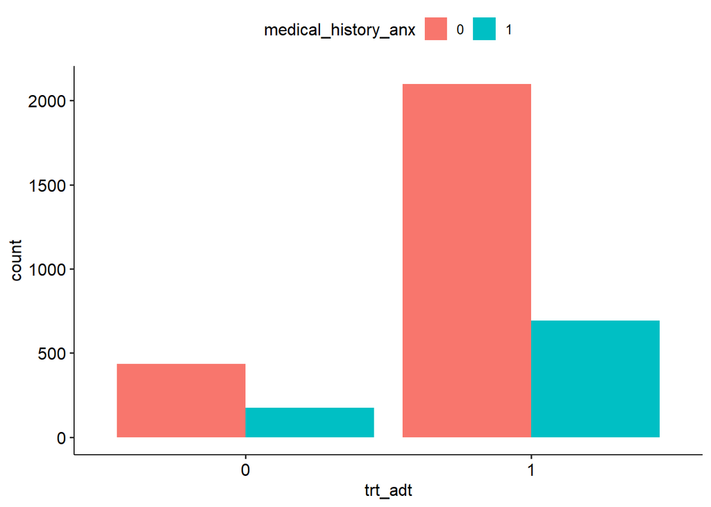

```r
ggplot(Data1, aes(trt_adt, after_stat(count))) + geom_bar(aes(fill = medical_history_anx), position = "dodge")
```

One other way of assessing binary variables faster is with a selection process.

```r
Data2 <- Data1[,c("trt_adt","medical_history_dia", "medical_history_sud","medical_history_hbp",
                  "medical_history_ren", "medical_history_tum", "medical_history_anx",
                  "medical_history_mood", "symptom_1", "symptom_2", "symptom_3",
                  "symptom_4","symptom_5","cgis_adm", "cgis_dis", "gaf_lv")]

no.na.data2 <- na.omit(Data2)


#define intercept-only model
i <- lm(trt_adt ~ 1, data=no.na.data2)

#define model with all predictors
all <- lm(trt_adt ~ ., data=no.na.data2)

#perform backward stepwise regression
backward <- step(all, direction='backward', scope=formula(all), trace=0)

#view results of backward stepwise regression
backward$anova
```

```
##                      Step Df     Deviance Resid. Df Resid. Dev       AIC
## 1                         NA           NA      2867   421.8536 -5522.788
## 2                - gaf_lv  7 0.5910340004      2874   422.4446 -5532.730
## 3              - cgis_dis  5 0.2077678009      2879   422.6524 -5541.305
## 4              - cgis_adm  6 1.2231645060      2885   423.8755 -5544.931
## 5  - medical_history_mood  1 0.0001158598      2886   423.8756 -5546.930
## 6             - symptom_5  1 0.0002468982      2887   423.8759 -5548.928
## 7   - medical_history_tum  1 0.0003697865      2888   423.8763 -5550.926
## 8             - symptom_4  1 0.0018666390      2889   423.8781 -5552.913
## 9             - symptom_1  1 0.0062344844      2890   423.8844 -5554.870
## 10  - medical_history_ren  1 0.0085418613      2891   423.8929 -5556.812
## 11  - medical_history_dia  1 0.0124206811      2892   423.9053 -5558.727
## 12            - symptom_3  1 0.0249464093      2893   423.9303 -5560.556
## 13  - medical_history_sud  1 0.0587180541      2894   423.9890 -5562.155
## 14  - medical_history_hbp  1 0.1302869854      2895   424.1193 -5563.265
## 15            - symptom_2  1 0.1587427526      2896   424.2780 -5564.180
```

```r
#view final model
backward$coefficients
```

```
##          (Intercept) medical_history_anx1
##            0.8292343           -0.0297727
```

From this backwards selection in finding what variables are predictive of antidepressants being given as treatment, a medical history of anxiety was the only predictive variable. It was also negatively correlated with antidepressants.

We can also do this for all other medication types

```r
Data3 <- Data1[,c("trt_con","medical_history_dia", "medical_history_sud","medical_history_hbp",
                  "medical_history_ren", "medical_history_tum", "medical_history_anx",
                  "medical_history_mood", "symptom_1", "symptom_2", "symptom_3",
                  "symptom_4","symptom_5","cgis_adm", "cgis_dis", "gaf_lv")]

no.na.data3 <- na.omit(Data3)


#define intercept-only model
i <- lm(trt_con ~ 1, data=no.na.data3)

#define model with all predictors
all <- lm(trt_con ~ ., data=no.na.data3)

#perform backward stepwise regression
backward <- step(all, direction='backward', scope=formula(all), trace=0)

#view results of backward stepwise regression
backward$anova
```

```
##                      Step Df     Deviance Resid. Df Resid. Dev       AIC
## 1                         NA           NA      2867   695.9569 -4071.963
## 2                - gaf_lv  7 1.5227104218      2874   697.4796 -4079.630
## 3              - cgis_adm  6 1.1319513442      2880   698.6115 -4086.930
## 4              - cgis_dis  5 1.2724202685      2885   699.8839 -4091.657
## 5   - medical_history_ren  1 0.0001310236      2886   699.8841 -4093.656
## 6   - medical_history_dia  1 0.0013306123      2887   699.8854 -4095.651
## 7   - medical_history_sud  1 0.0715332736      2888   699.9569 -4097.355
## 8             - symptom_4  1 0.1041718826      2889   700.0611 -4098.923
## 9             - symptom_2  1 0.1208987066      2890   700.1820 -4100.423
## 10            - symptom_3  1 0.1217865751      2891   700.3038 -4101.919
## 11  - medical_history_tum  1 0.1877019419      2892   700.4915 -4103.142
## 12            - symptom_1  1 0.1850755045      2893   700.6766 -4104.377
## 13 - medical_history_mood  1 0.2383618853      2894   700.9149 -4105.391
## 14            - symptom_5  1 0.2451283573      2895   701.1601 -4106.378
## 15  - medical_history_hbp  1 0.2504676038      2896   701.4105 -4107.343
```

```r
#view final model
backward$coefficients
```

```
##          (Intercept) medical_history_anx1
##            0.5777262            0.0386937
```

Here we find that treatment of anticonvulsants is only predicted by a history of anxiety disorder.

```r
Data4 <- Data1[,c("trt_the","medical_history_dia", "medical_history_sud","medical_history_hbp",
                  "medical_history_ren", "medical_history_tum", "medical_history_anx",
                  "medical_history_mood", "symptom_1", "symptom_2", "symptom_3",
                  "symptom_4","symptom_5","cgis_adm", "cgis_dis", "gaf_lv")]

no.na.data4 <- na.omit(Data4)


#define intercept-only model
i <- lm(trt_the ~ 1, data=no.na.data4)

#define model with all predictors
all <- lm(trt_the ~ ., data=no.na.data4)

#perform backward stepwise regression
backward <- step(all, direction='backward', scope=formula(all), trace=0)

#view results of backward stepwise regression
backward$anova
```

```
##                      Step Df     Deviance Resid. Df Resid. Dev       AIC
## 1                         NA           NA      2867   416.9485 -5556.682
## 2                - gaf_lv  7 0.8090927329      2874   417.7576 -5565.063
## 3              - cgis_adm  6 0.6293209703      2880   418.3869 -5572.701
## 4              - cgis_dis  5 0.7686212786      2885   419.1555 -5577.382
## 5   - medical_history_anx  1 0.0003915186      2886   419.1559 -5579.379
## 6   - medical_history_dia  1 0.0016493973      2887   419.1575 -5581.368
## 7             - symptom_2  1 0.0075841153      2888   419.1651 -5583.315
## 8             - symptom_3  1 0.0208808951      2889   419.1860 -5585.171
## 9   - medical_history_sud  1 0.0448851631      2890   419.2309 -5586.861
## 10  - medical_history_hbp  1 0.0490177848      2891   419.2799 -5588.522
## 11  - medical_history_tum  1 0.1066366043      2892   419.3865 -5589.785
## 12            - symptom_1  1 0.1450251799      2893   419.5316 -5590.783
## 13 - medical_history_mood  1 0.1615553590      2894   419.6931 -5591.667
## 14  - medical_history_ren  1 0.2505169440      2895   419.9436 -5591.938
```

```r
#view final model
backward$coefficients
```

```
## (Intercept)  symptom_41  symptom_51
##  0.82156662  0.02425805 -0.02933686
```

Here we can see that the symptoms upon presence are becoming more key factors here worth considering. Predictive of need of therapy is currently feeling depressed or hopeless and presence of suicidal thoughts. Suicidal thoughts however is negatively correlated.

```r
t <- table(Data1$trt_the, Data1$symptom_4)
chisq.test(t)
```

```
##
##  Pearson's Chi-squared test with Yates' continuity correction
##
## data:  t
## X-squared = 1.9146, df = 1, p-value = 0.1665
```

```r
t <- table(Data1$trt_the, Data1$symptom_5)
chisq.test(t)
```

```
##
##  Pearson's Chi-squared test with Yates' continuity correction
##
## data:  t
## X-squared = 1.073, df = 1, p-value = 0.3003
```

From the chi-squared tests however, they are not significantly correlated.

# What if we adjusted for gender, height, weight and race?

# What if we analysed the costings for each individual?

# What treatments are patients receiving in conjuntion?

# Are current symptoms related to medical history

# Does weight/height affect the analysis?

# Are there repeated visitors in the patients?

Thanks for reading,

Dr Sophia Halliday